# MVP Prediction: Initial Modeling

Kobe Sarausad

4/12/2022

# Predicting the NBA MVP using season stats and Twitter sentiment

First, let’s start by importing the necessary libraries.

```r
library(tidyverse) # data manipulation and plotting
library(tidymodels) # linear models
library(corrr) # analyze correlation
library(paletteer) # cool palette used in ISLR textbook
library(ggridges) # ridge plots
library(kableExtra) # nice tables
library(rtweet) # get tweets

theme_cons <- theme_minimal() +
  theme(text = element_text(family = "Titillium Web"))
```

As I am still in the initial stages of this project, I started off by scraping MVP data off [basketball-reference](https://www.basketball-reference.com/). Specifically, the players that are included in this model are players that received at least one MVP vote, and for each player there are summary season stats.

```r
mvp <- read.csv("mvpdata.csv")
head(mvp)
```

```
##   X Rank           Player Age  Tm First Pts.Won Pts.Max Share  G   MP  PTS  TRB
## 1 1    1 Shaquille O'Neal  27 LAL   120    1207    1210 0.998 79 40.0 29.7 13.6
## 2 2    2    Kevin Garnett  23 MIN     0     408    1210 0.337 81 40.0 22.9 11.8
## 3 3    3  Alonzo Mourning  29 MIA     0     367    1210 0.303 79 34.8 21.7  9.5
## 4 4    4      Karl Malone  36 UTA     0     312    1210 0.258 82 35.9 25.5  9.5
## 5 5    5       Tim Duncan  23 SAS     0     248    1210 0.205 74 38.9 23.2 12.4
## 6 6    6      Gary Payton  31 SEA     0     180    1210 0.149 82 41.8 24.2  6.5
##   AST STL BLK   FG.  X3P.   FT.   WS WS.48 season
## 1 3.8 0.5 3.0 0.574 0.000 0.524 18.6 0.283   2000
## 2 5.0 1.5 1.6 0.497 0.370 0.765 11.6 0.172   2000
## 3 1.6 0.5 3.7 0.551 0.000 0.711 12.9 0.226   2000
## 4 3.7 1.0 0.9 0.509 0.250 0.797 15.3 0.249   2000
## 5 3.2 0.9 2.2 0.490 0.091 0.761 13.0 0.218   2000
## 6 8.9 1.9 0.2 0.448 0.340 0.735 13.9 0.195   2000
```

I am also going to look to use FiveThirtyEight’s player evaluation score: RAPTOR. This could be a helpful feature in our prediction model, though it might be highly correlated with season stats. I was able to retreive this data directly off FiveThirtyEight’s [github repository](https://github.com/fivethirtyeight/data/tree/master/nba-raptor).

```r
raptor <- read.csv("https://raw.githubusercontent.com/fivethirtyeight/data/master/nba-raptor/historical_RAPTOR_by_player.csv")
head(raptor)
```

```
##           player_name player_id season poss   mp raptor_offense raptor_defense
## 1      Alaa Abdelnaby abdelal01   1991  640  303      -3.938450     -0.5100764
## 2      Alaa Abdelnaby abdelal01   1992 1998  959      -2.553849     -0.1979430
## 3      Alaa Abdelnaby abdelal01   1993 2754 1379      -2.373736     -2.0698079
## 4      Alaa Abdelnaby abdelal01   1994  320  159      -6.140056     -2.7483120
## 5      Alaa Abdelnaby abdelal01   1995  984  506      -3.846543     -1.2680122
## 6 Kareem Abdul-Jabbar abdulka01   1977 7674 3483       4.544044      3.1038547
##   raptor_total    war_total war_reg_season war_playoffs predator_offense
## 1    -4.448526 -0.265191008    -0.22616282  -0.03902819        -3.905732
## 2    -2.751792 -0.006892965     0.07032163  -0.07721460        -2.499576
## 3    -4.443544 -1.227189351    -0.84527175  -0.38191760        -2.328144
## 4    -8.888368 -0.500600277    -0.50060028   0.00000000        -5.820936
## 5    -5.114556 -0.615802282    -0.61580228   0.00000000        -3.715429
## 6     7.647899 18.488255000    15.45621631   3.03203869         4.762807
##   predator_defense predator_total pace_impact
## 1       -1.6967961      -5.602528   0.1992406
## 2       -0.7218763      -3.221452   0.4854362
## 3       -2.0022628      -4.330407   0.4882659
## 4       -3.5265600      -9.347496   0.5111522
## 5       -1.0270241      -4.742453   1.5459219
## 6        2.6245010       7.387308  -0.5029621
```

Now, we will join these two dataframes together. We’ll be joining by player but also make sure join by season as well since we don’t want RAPTOR scores from other seasons!

```r
mvp_raptor <- left_join(mvp, raptor, by = c("Player" = "player_name", "season"))
```

We can check for any NAs that might’ve resulted from the join…

```r
head(mvp_raptor[is.na(mvp_raptor$raptor_total), ])
```

```
##       X Rank          Player Age  Tm First Pts.Won Pts.Max Share  G   MP  PTS
## 51   51  16T Peja Stojaković  24 SAC     0       1    1260 0.001 71 37.3 21.2
## 68   68    4 Peja Stojaković  26 SAC     1     281    1230 0.228 81 40.3 24.2
## 134 134   10   Manu Ginóbili  30 SAS     0       9    1260 0.007 74 31.1 19.5
## 164 164   11   Manu Ginóbili  32 SAS     0       3    1230 0.002 75 28.7 16.5
## 176 176    8   Manu Ginóbili  33 SAS     0      20    1210 0.017 80 30.3 17.4
## 228 228   16    Goran Dragić  27 PHO     0       3    1250 0.002 76 35.1 20.3
##     TRB AST STL BLK   FG.  X3P.   FT.   WS WS.48 season player_id poss mp
## 51  5.3 2.5 1.1 0.2 0.484 0.416 0.876  9.9 0.179   2002      <NA>   NA NA
## 68  6.3 2.1 1.3 0.2 0.480 0.433 0.927 13.5 0.198   2004      <NA>   NA NA
## 134 4.8 4.5 1.5 0.4 0.460 0.401 0.860 11.1 0.232   2008      <NA>   NA NA
## 164 3.8 4.9 1.4 0.3 0.441 0.377 0.870  9.7 0.216   2010      <NA>   NA NA
## 176 3.7 4.9 1.5 0.4 0.433 0.349 0.871  9.9 0.195   2011      <NA>   NA NA
## 228 3.2 5.9 1.4 0.3 0.505 0.408 0.760 10.3 0.186   2014      <NA>   NA NA
##     raptor_offense raptor_defense raptor_total war_total war_reg_season
## 51              NA             NA           NA        NA             NA
## 68              NA             NA           NA        NA             NA
## 134             NA             NA           NA        NA             NA
## 164             NA             NA           NA        NA             NA
## 176             NA             NA           NA        NA             NA
## 228             NA             NA           NA        NA             NA
##     war_playoffs predator_offense predator_defense predator_total pace_impact
## 51            NA               NA               NA             NA          NA
## 68            NA               NA               NA             NA          NA
## 134           NA               NA               NA             NA          NA
## 164           NA               NA               NA             NA          NA
## 176           NA               NA               NA             NA          NA
## 228           NA               NA               NA             NA          NA
```

In fact, we do have some error as names in the raptor dataset don’t contain accented letters. Let’s replace these letters with non accented letters.

```r
players_accent <- unique(mvp_raptor[is.na(mvp_raptor$raptor_total), ]$Player)
players_no_accent <- str_remove(iconv(players_accent, to='ASCII//TRANSLIT'), "'")
players_replace <- data.frame(players_accent, players_no_accent)

mvp_clean <- mvp_raptor %>%
  filter(is.na(raptor_total)) %>%
  left_join(players_replace, by = c("Player" = "players_accent")) %>%
  mutate(Player = players_no_accent) %>%
  select(-players_no_accent) %>%
  rbind(mvp_raptor[complete.cases(mvp_raptor), ])

mvp_clean <- left_join(mvp_clean[, c(1:22)], raptor, by = c("Player" = "player_name", "season"))

mvp_clean[is.na(mvp_clean$raptor_total), ]
```

```
##  [1] X                Rank             Player           Age
##  [5] Tm               First            Pts.Won          Pts.Max
##  [9] Share            G                MP               PTS
## [13] TRB              AST              STL              BLK
## [17] FG.              X3P.             FT.              WS
## [21] WS.48            season           player_id        poss
## [25] mp               raptor_offense   raptor_defense   raptor_total
## [29] war_total        war_reg_season   war_playoffs     predator_offense
## [33] predator_defense predator_total   pace_impact
## <0 rows> (or 0-length row.names)
```

Now that the data is cleaned, we can explore our data a bit.

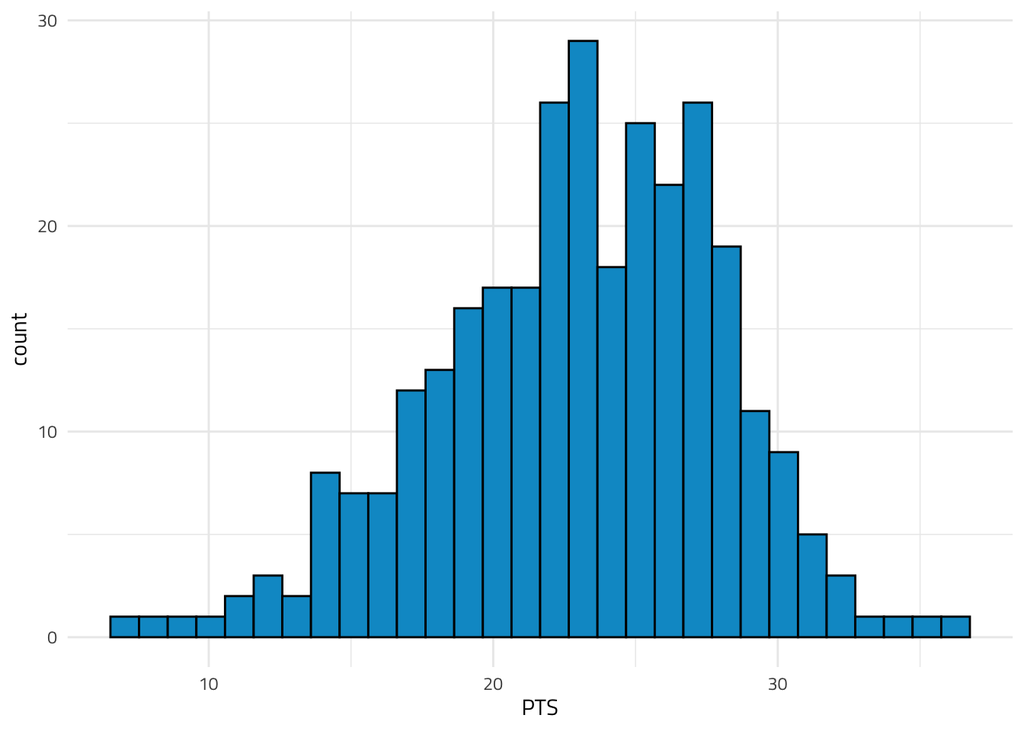

```r
mvp_clean %>%
  ggplot() +
  geom_histogram(aes(x = PTS), fill = "deepskyblue3", color = "black") +
  theme_cons
```

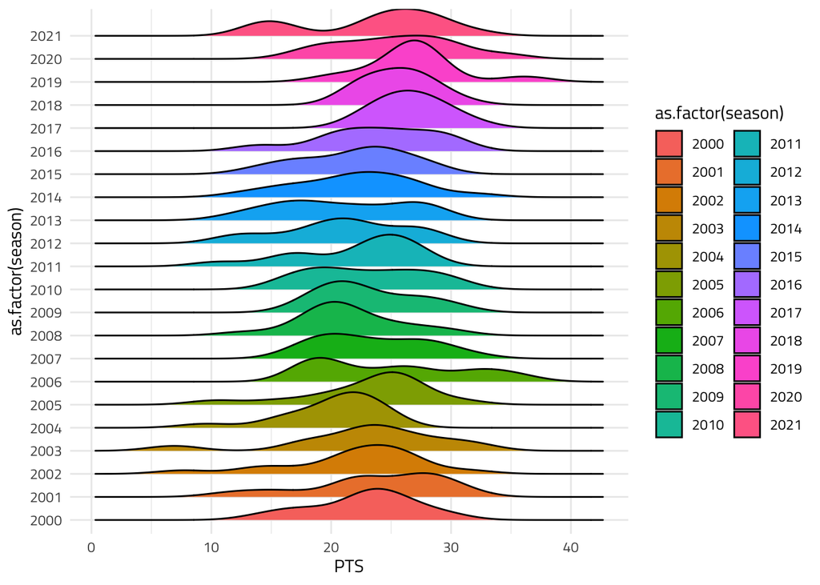

```r
mvp_clean %>%
  ggplot() +
  geom_density_ridges(aes(x = PTS, y = as.factor(season), fill = as.factor(season))) +
  theme_cons
```

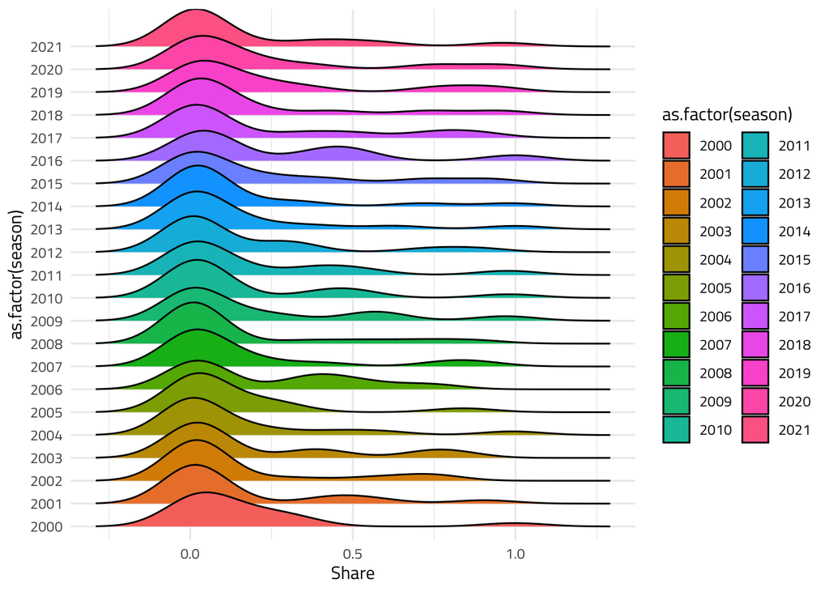

```r
mvp_clean %>%
  ggplot() +
  geom_density_ridges(aes(x = Share, y = as.factor(season), fill = as.factor(season))) +
  theme_cons
```

Now, we are ready to test features!

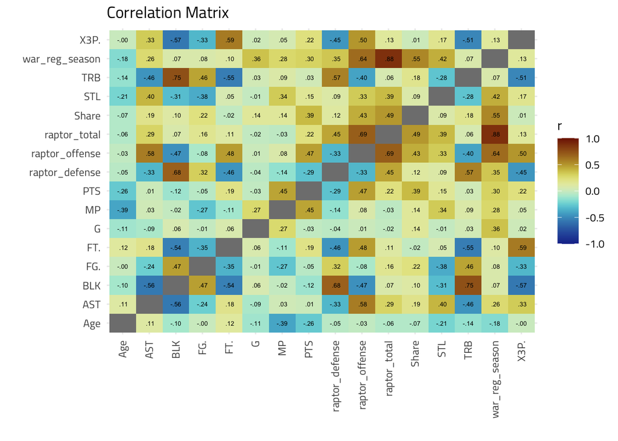

```r
features <- c("Age", names(mvp_clean)[c(10:19)], "raptor_total", "raptor_defense", "raptor_offense", "war_reg_season")

corr_mvp <- mvp_clean %>%
  select(features, Share) %>%
  correlate()

corr_mvp %>%
  stretch() %>%
  ggplot(aes(x,y, fill = r)) +
  geom_tile() +
  geom_text(aes(x, label = as.character(fashion(r))), size = 1.8) +
  scale_fill_paletteer_c("scico::roma", limits = c(-1, 1), direction = -1) +
  labs(x = "", y = "", title = "Correlation Matrix") +
  theme_cons +
  theme(axis.text.x = element_text(angle = 90, vjust = 0.5, hjust=1))
```

We can observe that there are a couple of features that might become good predictors of MVP share count. Let’s split our data into test and train.

```r
set.seed(1)
split <- initial_split(mvp_clean, strata = Share, prop = 0.5)
mvp_train <- training(split)
mvp_test <- testing(split)
```

Then, we can specify our model

```r
# Specify model
lm_spec <- linear_reg() %>%
  set_mode("regression") %>%
  set_engine("lm")

# Fit model
mvp_model <- lm_spec %>%
  fit(Share ~ PTS + raptor_total + war_reg_season, data = mvp_train)
```

Compute RMSE for test/train

```r
train_error <- augment(mvp_model, new_data = mvp_train) %>%
  rmse(truth = Share, estimate = .pred) %>%
  select(.estimate)

test_error <- augment(mvp_model, new_data = mvp_test) %>%
  rmse(truth = Share, estimate = .pred) %>%
  select(.estimate)

mse <- data.frame(train_error^2, test_error^2)
colnames(mse) <- c("Train Error", "Test Error")
```

Since we are working with proportions (values between 0-1), square rooting the value actually makes the value bigger, so let’s square the RMSE to just get the MSE.

```r
mse %>%
  kable() %>%
  kable_styling(full_width = FALSE)
```

| Train Error | Test Error |
| --- | --- |
| 0.0525389 | 0.0490342 |

Not too bad, but not too great at the same time.

However, we have ran into a problem: we can’t query tweets past the one-week period, thus not allowing us to get tweets from 2005. But, we can get tweets from past dates if we specify a search term. That got me thinking to think a way around this problem, then I thought that by querying multiple news outlet Twitter accounts, we may be able to get the sentiment of the “media”.

```r
# poly_tuned_rec <- recipe(Share ~ PTS + raptor_total + war_reg_season, data = mvp_train) %>%
#   step_poly(PTS, degree = tune())
#
# poly_tuned_wf <- workflow() %>%
#   add_recipe(poly_tuned_rec) %>%
#   add_model(lm_spec)
#
# fit(poly_tuned_wf, data = mvp_train)
# mvp_folds <- vfold_cv(mvp_train, v = 10)
#
# # degree_grid <- grid_regular(degree(range = c(1, 10)), levels = 10)
# degree_grid <- tibble(degree = seq(1, 10))
#
# tune_res <- tune_grid(
#   object = poly_tuned_wf,
#   resamples = mvp_folds,
#   grid = degree_grid
# )
#
# autoplot(tune_res)
```